# Project: Investigate a Dataset - [ TMDb movie data ]

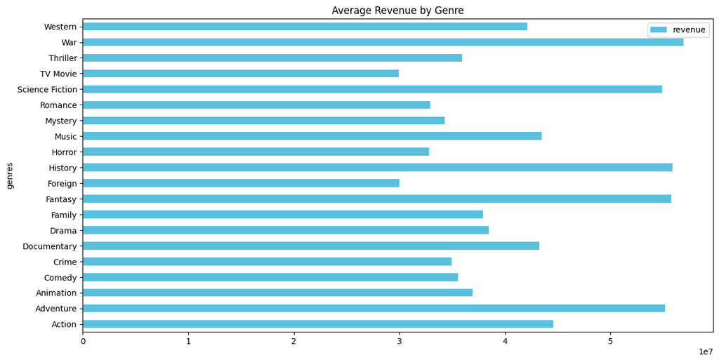

```python
# Plot the average revenue by genre
genre_revenue.plot(
    kind='barh',
    x='genres',
    y='revenue',
    figsize=(14, 7),
    title='Average Revenue by Genre',
    color='#5bc0de'
);
```

Based on the above horizontal bar plot, the movie genres with the highest revenues are: War, History, Fantasy, and Adventure. While the genres with the lowest revenues are: TV Mvoie and Foreign

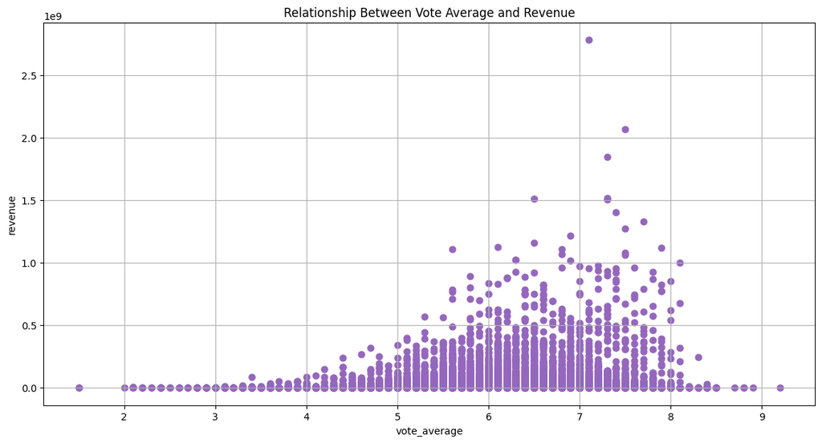

```python
# Plot the relationship between revenue and vote average
data.plot(
    kind='scatter',
    x='vote_average',
    y='revenue',
    figsize=(14, 7),
    grid=True,
    title='Relationship Between Vote Average and Revenue',
    color='C4',
    s=40
)
```

The scatter plot illustrates the relationship between average vote scores & revenues. It shows a positive correlation between vote average and revenues, meaning that higher-rated movies are generally more successful in terms of revenue. Overall, while higher vote averages can be associated with higher revenues, there is significant variability. Movies with moderate vote averages (5-7) are common and exhibit a wide range of revenue outcomes. High vote averages (above 7) are less common but can correlate with high revenue, although not uniformly.

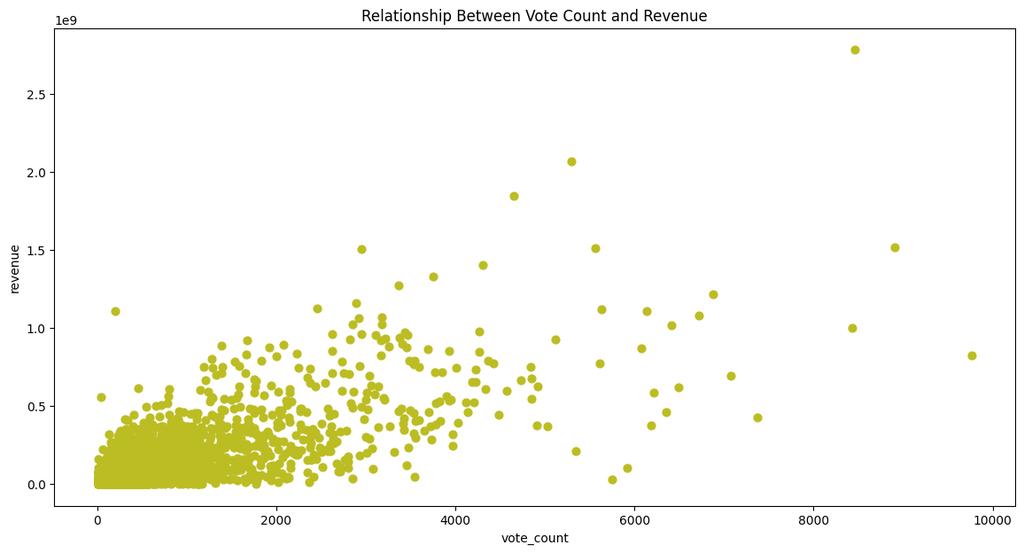

```python
# Plot the relationship between revenue and vote count
data.plot(
    kind='scatter',
    x='vote_count',
    y='revenue',
    figsize=(14, 7),
    title='Relationship Between Vote Count and Revenue',
    color='C8',
    s=40
)
```

The scatter plot shows the relationship between vote count and revenue for movies. Overall, there is a positive correlation between vote count and revenue, with movies that receive more votes generally tending to earn higher revenues. However, the variability in revenue remains high across all vote count ranges, indicating that while higher vote counts can be associated with higher revenues, it is not a guaranteed outcome.

## Conclusions

*After performing data cleaning,I have moved on to exploration where I created visualizations. Also, I have performed both single-variable (1d) and multiple-variable (2d) explorations focusing on two questions.*

#### *Summary of Findings*

**How has the popularity of movies changed over the years?**

- *The analysis shows that movie popularity has varied significantly over time. The average popularity of movies saw a remarkable increase in 2015 compared to previous years. This trend can be visualized in the bar plot showing average movie popularity over the years. The histogram of movie popularity indicates that most movies have low popularity scores, with only a few achieving high popularity.*
- *Further exploration into the popularity of different genres over time reveals additional insights. For instance, the "Music" genre was particularly popular between 1970 and 1980, while "Crime" and "Fantasy" genres saw a rise in popularity during the 1980s. Overall, the popularity of movies has fluctuated, showing peaks and declines across different periods and genres.*

**What kinds of properties are associated with movies that have high revenues?**

*The analysis reveals several properties associated with high-revenue movies:*

- **Budget:** There is a general trend showing that higher-budget movies tend to generate higher revenues. The scatter plot depicting the relationship between budget and revenue indicates that as the budget increases, revenue generally increases too, although with significant variability. This means not all high-budget movies guarantee high revenue.
- **Genres:** Certain genres are more likely to generate high revenues. The analysis shows that genres such as War, History, Fantasy, and Adventure have the highest average revenues. In contrast, TV Movie and Foreign genres tend to have the lowest revenues.
- **Vote Average:** Movies with higher average ratings tend to earn higher revenues. The scatter plot showing the relationship between vote average and revenue indicates a positive correlation, meaning that better-rated movies are generally more successful financially.
- **Vote Count:** Movies that receive more votes also tend to have higher revenues. The scatter plot of vote count versus revenue shows a positive correlation, suggesting that movies that attract more audience engagement (as indicated by vote count) generally achieve higher revenues.

**Additional Information and Further Research**

While the analysis provides valuable insights, there are limitations that should be addressed for more comprehensive results:

- **Data Completeness and Representation:** The dataset may not fully represent all movies, especially independent or low-budget films, potentially leading to bias in the analysis.
- **Temporal Analysis Limitation:** If certain periods have more movies recorded than others, it might create biases in temporal trend analysis.
- **Data Aggregation:** Adjusting financial figures for inflation and ensuring consistent reporting standards across different periods would enhance the accuracy of the financial analysis.
- **Genre Distribution:** A deeper dive into underrepresented genres could help mitigate potential biases towards popular genres in the analysis.

code resources: https://stackoverflow.com/ https://python-graph-gallery.com/

```python
# Running this cell will execute a bash command to convert this notebook to an .html file
!python -m nbconvert --to html Investigate_a_Dataset.ipynb
```

```
[NbConvertApp] Converting notebook Investigate_a_Dataset.ipynb to html
[NbConvertApp] WARNING | Alternative text is missing on 11 image(s).
[NbConvertApp] Writing 1207245 bytes to Investigate_a_Dataset.html
```